# Graduate_project

Emmenta Janneh, Alphonso Saiewane, and Silvy Saint-Jane

2024-04-30

# Introduction

In today’s economic landscape, the accurate reporting and management of revenue tax payments are paramount for both governmental bodies and businesses alike. The complexity of tax systems, coupled with evolving regulatory requirements, presents challenges in ensuring compliance and maximizing revenue collection efficiency. Traditional methods of tax reporting often suffer from inefficiencies, inaccuracies, and lack of transparency, leading to potential revenue loss and regulatory scrutiny.

This project aims to address these challenges by leveraging data-driven approaches to streamline revenue tax payment reporting processes. By harnessing the power of data analytics using R and SQL, we seek to optimize tax reporting workflows, enhance accuracy, and provide actionable insights for stakeholders involved in revenue tax management.

## Data

Our data is from a real-world revenue collection flat-file from January to March of 2024. For security reasons, the company name have been omitted from the data set leaving only their TIN numbers for identification.

```r
revenue <- read.csv("revenue.csv")
glimpse(revenue)
```

```
## Rows: 17,869
## Columns: 9
## $ TIN         <int> 50080451, 50080451, 50080451, 400262004, 404492004, 404492…
## $ CBO         <chr> "Freeport", "Freeport", "Freeport", "Freeport", "LPRC", "L…
## $ TAX.CODE    <chr> "115114", "115127", "115111", "141598", "115139", "115129"…
## $ TAX.KIND    <chr> "ECOWAS trade levy", "GST on imported goods (excluding pet…
## $ PAY.DATE    <chr> "1/17/2024", "1/17/2024", "1/17/2024", "3/12/2024", "3/25/…
## $ Rate        <dbl> 187.17, 187.17, 187.17, 191.43, 191.43, 191.43, 191.43, 19…
## $ Consol.     <chr> " 33.23 ", " 770.77 ", " 1,041.68 ", "3000", "22455", "299…
## $ RECEIPT.NO  <chr> "2024R793", "2024R793", "2024R793", "2024R3533", "2024RR18…
## $ Description <chr> "Teller OneStop", "Teller OneStop", "Teller OneStop", "Tel…
```

The data set consist of 17,869 records of tax payment, and 9 columns. Description of the column variables are:

- TIN: Tax identification number
- CBO: Cooperate business office
- TAX_CODE: Tax code the identifies the tax kind
- TAX_KIND: The type or kind of tax paid
- PAY_DATE: The date payment was made
- Rate: The exchange rate from local to USD
- Consol.: The amount of payment in USD
- RECEIPT.NO: The receipt number
- Description: Payment description

## Data Cleaning and Formating

We decided to remove all redundant columns (example TAX.CODE) to avoid complications, proper formatting of columns were made, and all NULL Consol. values or 0 value rows were removed using `dplyr`

```r
revenue <- rename(revenue, "Tax_code" = "TAX.CODE", "Tax_Kind" = "TAX.KIND", "Receipt_NO" = "RECEIPT.NO", "Amount" = "Consol.", "Pay_Date" = "PAY.DATE")

revenue <- revenue |> mutate(
                  Tax_Kind = factor(Tax_Kind),
                  TIN = factor(TIN),
                  CBO = factor(CBO),
                  Pay_Date = as.Date(Pay_Date, format = "%m/%d/%Y"),
                  Amount = as.numeric(gsub(",", "", Amount))
) |>
  filter(Amount > 0) |>
  select(- Tax_code) |>
  glimpse()
```

```
## Rows: 15,917
## Columns: 8
## $ TIN         <fct> 50080451, 50080451, 50080451, 400262004, 404492004, 404492…
## $ CBO         <fct> Freeport, Freeport, Freeport, Freeport, LPRC, LPRC, LPRC, …
## $ Tax_Kind    <fct> ECOWAS trade levy, GST on imported goods (excluding petrol…
## $ Pay_Date    <date> 2024-01-17, 2024-01-17, 2024-01-17, 2024-03-12, 2024-03-2…
## $ Rate        <dbl> 187.17, 187.17, 187.17, 191.43, 191.43, 191.43, 191.43, 19…
## $ Amount      <dbl> 33.23, 770.77, 1041.68, 3000.00, 22455.00, 29940.00, 29940…
## $ Receipt_NO  <chr> "2024R793", "2024R793", "2024R793", "2024R3533", "2024RR18…
## $ Description <chr> "Teller OneStop", "Teller OneStop", "Teller OneStop", "Tel…
```

# Reporting Analysis

## Summary Statistics

First we choose to look at a summary statistics for each column in the data set.

```r
summary_stat <- summary(revenue)
print(summary_stat)
```

```
##         TIN              CBO
##  500036301:  605   Freeport:13481
##  500031921:  306   RIA     : 1397
##  500033821:  239   LPRC    :  931
##  500008537:  221   Buchanan:   62
##  500004700:  200   Harper  :   23
##  500002043:  154   Loguatuo:   10
##  (Other)  :14192   (Other) :   13
##                                                  Tax_Kind
##  ECOWAS trade levy                                   :4863
##  GST on imported goods (excluding petroleum)         :3752
##  Import duties on goods other than rice and petroleum:3698
##  Other import duties                                 : 972
##  Customs user fees                                   : 769
##  Excise tax on cosmetics (imported)                  : 376
##  (Other)                                             :1487
##     Pay_Date               Rate           Amount        Receipt_NO
##  Min.   :2024-01-02   Min.   :187.2   Min.   :     0   Length:15917
##  1st Qu.:2024-01-26   1st Qu.:188.4   1st Qu.:   110   Class :character
##  Median :2024-02-16   Median :189.5   Median :  1120   Mode  :character
##  Mean   :2024-02-16   Mean   :189.2   Mean   :  3499
##  3rd Qu.:2024-03-07   3rd Qu.:191.4   3rd Qu.:  2743
##  Max.   :2024-03-30   Max.   :191.4   Max.   :312166
##
##  Description
##  Length:15917
##  Class :character
##  Mode  :character
##
##
##
##
```

## Trend - Which companies are the highest revenue payers over the three months?

For this analysis, we rearrange the data to fit consistent tax payers and producing a bar chart for simple visualization for top executive officers.

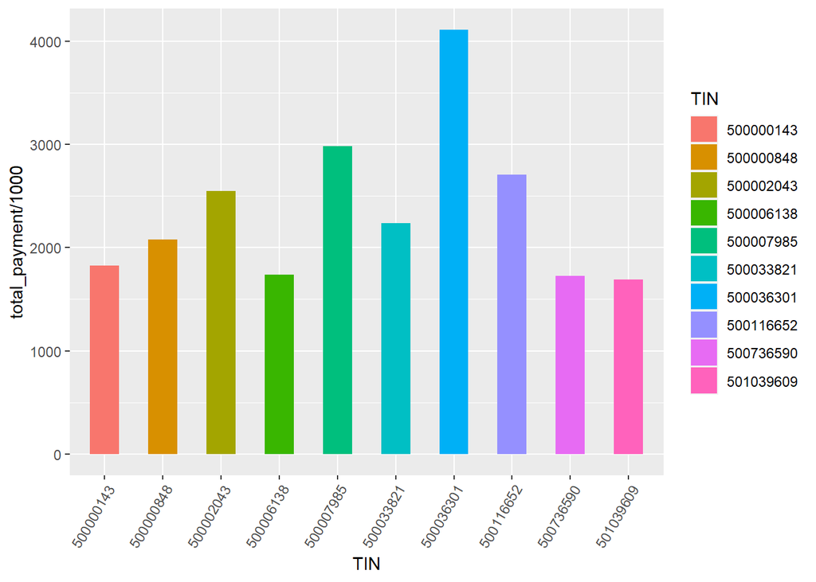

```r
top_payers <- as.data.frame(revenue)
top_payers$month_year <- format(top_payers$Pay_Date, "%Y-%m")

top_payers <- top_payers |> group_by(month_year, TIN) |> summarise(total_payment = sum(Amount)) |> ungroup()

total_unique_months <- length(unique(top_payers$month_year))

company_month_counts <- top_payers |>
  group_by(TIN) |>
  summarise(unique_months = n_distinct(month_year))

companies_with_all_months <- company_month_counts |>
  filter(unique_months == total_unique_months)

loopi <- companies_with_all_months$TIN

trend <- data.frame()
for(i in loopi){
  trend <- rbind(trend, filter(top_payers, TIN == i))
}

top_10 <- trend |>
  group_by(TIN) |>
  summarise(total_payment = sum(total_payment)) |>
  arrange(desc(total_payment)) |>
  top_n(10, total_payment)

ggplot(top_10, aes(x = TIN, y = total_payment/1000, fill = TIN)) +
  geom_bar(stat = "identity", width = 0.5) +
  theme(axis.text.x = element_text(angle = 60, hjust = 1))
```

## Trend - What is the payment flow for these top ten companies?

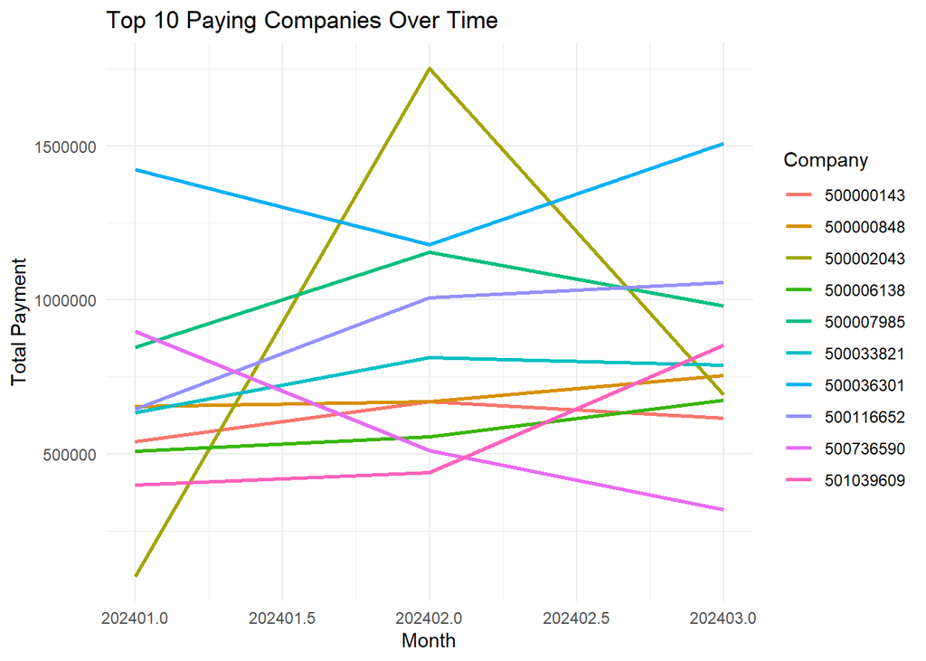

```r
loopj <- top_10$TIN

trending_10 <- data.frame()
for(j in loopj){
  trending_10 <- rbind(trending_10, filter(top_payers, TIN == j))
}

convert_to_numeric <- function(date_string) {
  # Split the string by "-"
  date_parts <- strsplit(date_string, "-")[[1]]

  # Extract year and month
  year <- as.numeric(date_parts[1])
  month <- as.numeric(date_parts[2])

  # Combine year and month into a numeric value
  numeric_value <- year * 100 + month

  return(numeric_value)
}

# Apply the function to each date string
trending_10$ndate <- sapply(trending_10$month_year, convert_to_numeric)

ggplot(trending_10, aes(x = ndate, y = total_payment, color = TIN)) +
  geom_line(linewidth = 1) +
  labs(title = "Top 10 Paying Companies Over Time",
       x = "Month",
       y = "Total Payment",
       color = "Company") +
  theme_minimal()
```

## What is the payment distribution amongst the CBOs for each tax kind?

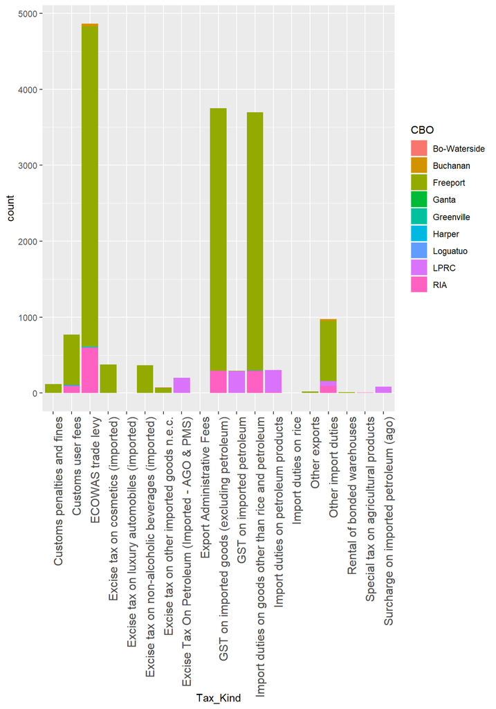

```r
ggplot(revenue, aes(x = Tax_Kind, fill = CBO)) +
  geom_bar() +
  theme(axis.text.x = element_text(angle = 90, hjust = 1, size = 12))
```

## Plot a graph for Amount on individual payment description

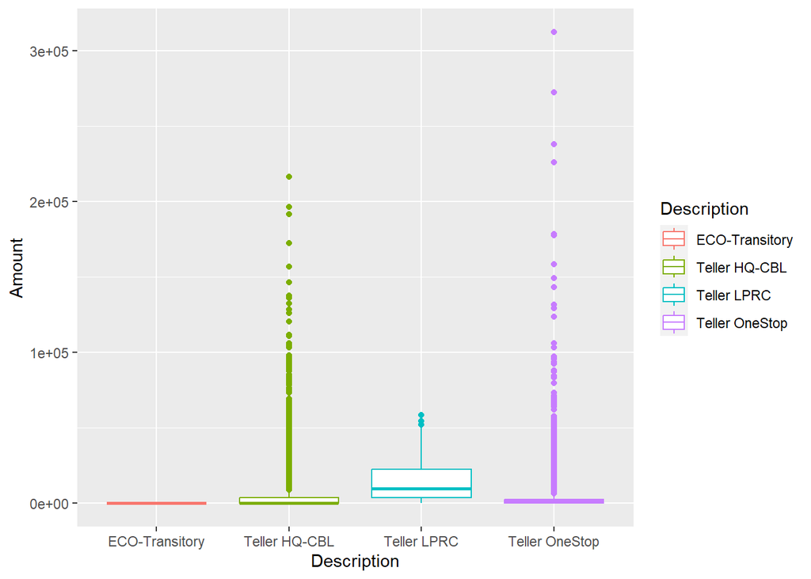

```r
ggplot(revenue, aes(x = Description, y = Amount, color = Description)) +
  geom_boxplot()
```

## Plot a payment on date graph, categorizing by payment description.

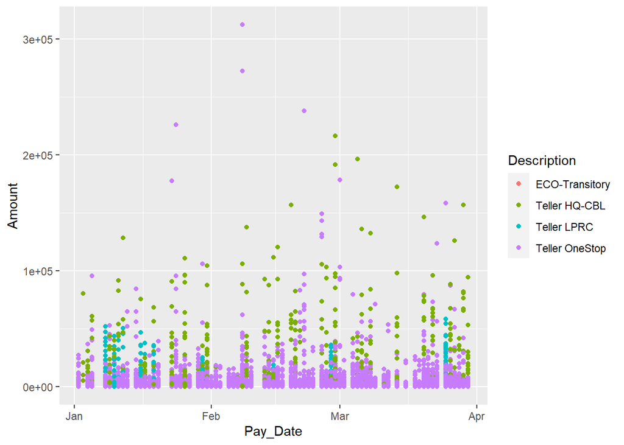

```r
ggplot(revenue, aes(x = Pay_Date, y = Amount, color = Description)) +
  geom_point()
```

# SQL Analysis

## Top 10 highest revenue collected for each month

```r
monthly_ten <- sqldf("SELECT * FROM
          (SELECT 'January' AS Month, TIN, total_payment FROM top_payers WHERE month_year == '2024-01' ORDER BY total_payment DESC LIMIT 10)
      UNION
SELECT * FROM
        (SELECT 'February' AS Month, TIN, total_payment FROM top_payers WHERE month_year == '2024-02' ORDER BY total_payment DESC LIMIT 10)
      UNION
SELECT * FROM
        (SELECT 'March' AS Month, TIN, total_payment FROM top_payers WHERE month_year == '2024-03' ORDER BY total_payment DESC LIMIT 10) ORDER BY total_payment
")

print(monthly_ten)
```

```
##       Month       TIN total_payment
## 1   January 500031921      426350.0
## 2  February 501039609      438392.9
## 3   January 500006138      508556.5
## 4  February 500736590      510722.4
## 5   January 500000143      540896.3
## 6     March 501028425      544982.6
## 7  February 500006138      555967.2
## 8     March 500000143      616527.3
## 9   January 500033821      633098.0
## 10  January 500116652      644401.2
## 11  January 500000848      653965.0
## 12 February 500000143      670179.2
## 13 February 500000848      670427.8
## 14    March 500006138      674742.5
```

[output cut: 16 more lines]

### Plot

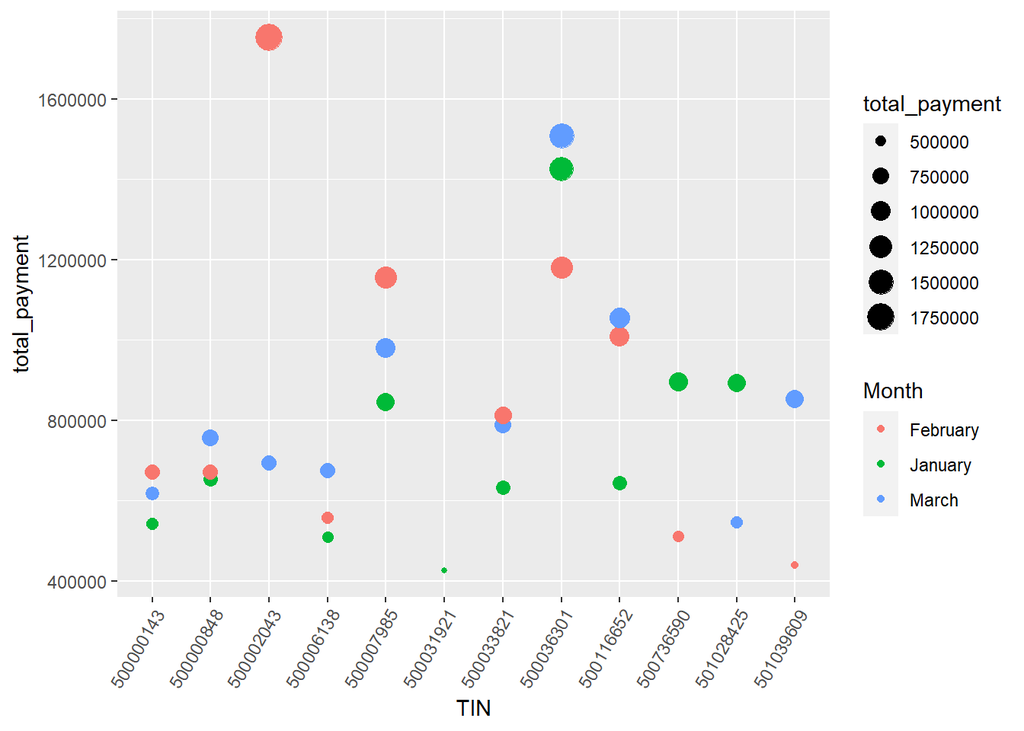

```r
ggplot(monthly_ten, aes(x = TIN, y = total_payment, color = Month, size = total_payment)) +
  geom_point() +
  theme(axis.text.x = element_text(angle = 60, hjust = 1))
```

## The most frequent tax description

```r
sqldf("SELECT DISTINCT(Description), COUNT(Description) AS Freq FROM revenue GROUP BY Description ORDER BY Freq DESC")
```

```
##      Description  Freq
## 1 Teller OneStop 13384
## 2  Teller HQ-CBL  2252
## 3    Teller LPRC   277
## 4 ECO-Transitory     4
```

## Display CBO in hierarchy of Tax collection

```r
sqldf("SELECT DISTINCT(CBO), SUM(Amount) AS Total_Tax_Collection FROM revenue GROUP BY CBO ORDER BY Total_Tax_Collection DESC")
```

```
##            CBO Total_Tax_Collection
## 1     Freeport          35448358.82
## 2         LPRC          18214246.39
## 3     Buchanan           1391723.73
## 4          RIA            485049.54
## 5     Loguatuo             66330.91
## 6       Harper             37295.70
## 7        Ganta             19687.78
## 8   Greenville             14295.43
## 9 Bo-Waterside             12285.08
```